# Tales of Defiance To Mind Control in the Modern Age

## Course Description

Are you concerned about the increasingly sophisticated ways social forces are attempting to control your mind? In this course we examine four different mind control scenarios as depicted in four seminal works of fiction. In each case, the lead character seeks to defiantly challenge a specific threat to mental autonomy. Taken together, these works of fiction (three films and a short story) trace an arc of defiance against increasingly sophisticated and multi-layered methods of thought control.

We begin with a filmed one-man play version of Fyodor Dostoevsky’s *Notes from the Underground* – a visceral scream against a world that imposes rationalism as the highest ideal. Next, in a film adaptation of George Orwell’s *1984*, “Big Brother” uses totalitarianism and a vocabulary of submission to colonize the inner self. From there we enter the digital age with *The Matrix* (the Wachowskis’ 1999 film), exploring an engineered reality that replaces the physical world entirely. Finally, Ken Liu’s short story *The Perfect Match* (2012) confronts invisible control through the “corporate nudge” of algorithms and big data.

Applying literary analysis, philosophy, and social theory, we examine how power and psychology shape what we call “real.” In discussing these narratives, we aim to build the intellectual muscles that each of us needs to navigate a world fractured by algorithms, social media, and the onslaught of AI, all the while resisting the persistent pull of old-fashioned ideological brainwashing.

## Course Topics, by week

Week 1: Overview of increasingly sophisticated, multi-layered arc of stories and lenses.

- Each week we will see a different kind of societally imposed mind control.
- We will discuss how each story presents a specific realization of a general pattern by which this type of mind control works.
- This will help clarify how this type of control is still relevant today.
- Class will discuss how the stories move them and reflect on how participants understand, work within, or rebel against this type of control.

Week 2: “Notes From The Underground”:

- Feelings/complexity are suppressed by dominance of simple rationalism.
- Early enlightenment models of deeply surveilled prisons and mental hospitals used to isolate and outcast people with “crazy” thoughts.
- Who controls what thoughts are “acceptable” controls the perceived reality.

Week 3: “1984”:

- Independent thoughts and feelings are disallowed under totalitarianism.
- This is enforced by surveillance and control of language and media.
- Who controls the narrative controls the perceived reality.

Week 4: “The Matrix”:

- The nature of reality itself is replaced by a computer simulation.
- People cannot even perceive that their reality is constructed.
- Who controls information we receive controls the perceived reality.

Week 5: “The Perfect Match”:

- Independent thoughts and feeling are not possible because algorithm and bots constantly “nudge” people what to think and feel.
- We are lured by comfort of a constructed, false-but-pleasant narrative.
- Who provides the most comfort controls the perceived reality.
- Pulling it all together and looking forward.

# Course Materials (e.g. readings, videos, digital images):

Note: Each Link below opens in a new browser tab.

- [“Notes From The Undeground”, one man show starring Larry Cedar, free on youtube](https://www.youtube.com/watch?v=asp5tqDql0g)

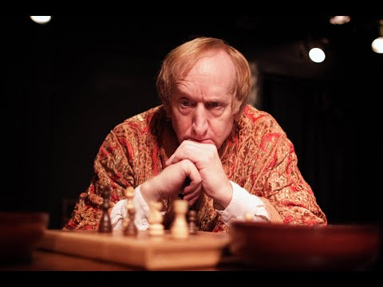

[▶ Watch on YouTube](https://www.youtube.com/watch?v=asp5tqDql0g)

- [“1984” movie directed by Michael Radford, free on tubitv](https://tubitv.com/movies/300443/1984?resume_time=1)

[figure not shown]

[▶ Watch Free on Tubi](https://tubitv.com/movies/300443/1984?resume_time=1)

- *The Matrix* movie, written and directed by the Wachowskis
  - [$3.99 to rent on YouTube](https://www.youtube.com/watch?v=GuE0Mtr-w6g)
    - need to create a free YouTube login to do this
  - [$3.99 to rent, $14.99 to buy on Amazon Prime Video](https://www.amazon.com/gp/video/detail/B0B6DB8G7C/ref=atv_dp_amz_c_yxuuUK_1_1)
    - need an Amazon Prime account to do this

[figure not shown]

[▶ Rent on YouTube](https://www.youtube.com/watch?v=GuE0Mtr-w6g)

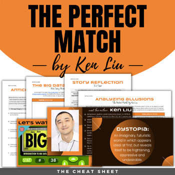

- Additional/optional materials will be provided on the class website or by email links.

## Objectives

Students should develop skills for analyzing and discussing various methods of societally imposed mind control. We study strategies for reacting to mental influences. Students should come away with a better sense of how their strategies are adapted to their personality type.

## SGL Biography

In his career as a mathematical physicist, Scott Axelrod studied geometrical quantum field theories as an assistant professor of mathematics at MIT, before working on nuclear magnetic resonance, natural language processing, and finance in industry. On the humanistic side, Scott has self-published books “Off the Deep End: Diary of a Mathematician”, “Infinite Regress”, and “After-Time”. Much of the latter book consists of essays for the BOLLI Writers Guild. He has several other works in progress. Scott is looking forward to his first-time teaching experience at BOLLI.